# Biostat 203B Homework 2

Due Feb 12 @ 11:59PM

Dominic Shehtanian

```r
knitr::opts_chunk$set(echo = TRUE, cache = TRUE)
library(tidyverse)
library(data.table)
library(lubridate)
os <- sessionInfo()$running
if (str_detect(os, "Linux")) {
  mimic_path <- "/usr/203b-data"
} else if (str_detect(os, "Windows")) {
  mimic_path <- "C:/Users/dsheh/Desktop"
}
```

## Q1. PhysioNet credential

At this moment, you should already get credentialed on the PhysioNet. Please include a screenshot of your `Data Use Agreement for the MIMIC-IV (v0.4)`.

**Solution:**

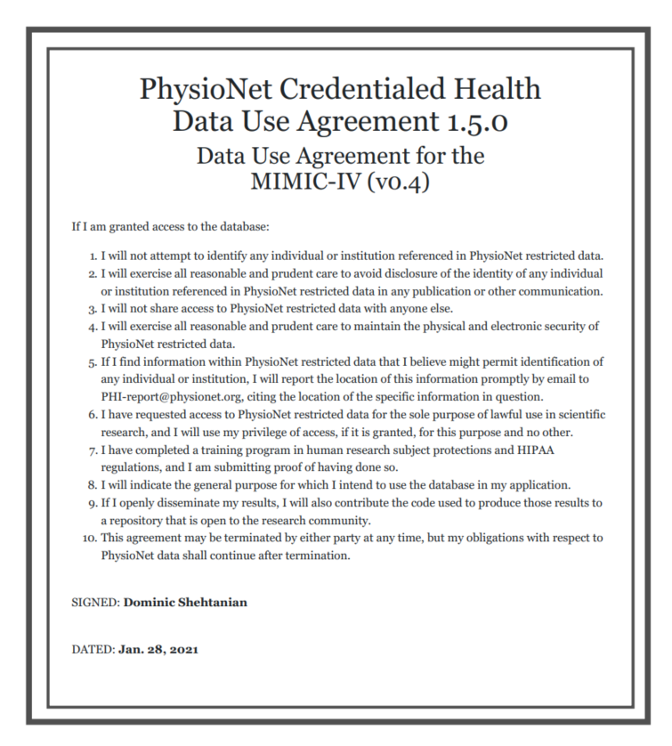

PhysioNet Credential

Note: In order for the image to appear when this document is knitted, the image file (credential.PNG) must be in same directory as this RMarkdown file. I have also committed a PDF of the Data Use Agreement to GitHub as well.

## Q2. `read.csv` (base R) vs `read_csv` (tidyverse) vs `fread` (data.table)

There are quite a few utilities in R for reading data files. Let us test the speed of reading a moderate sized compressed csv file, `admissions.csv.gz`, by three programs: `read.csv` in base R, `read_csv` in tidyverse, and `fread` in the popular data.table package. Is there any speed difference?

In this homework, we stick to the tidyverse.

**Solution:**

```r
system.time(read.csv(str_c(mimic_path, "/mimic-iv/core/admissions.csv.gz"),
  header=TRUE))
```

```
##    user  system elapsed
##    8.34    0.11    8.50
```

```r
system.time(read_csv(str_c(mimic_path, "/mimic-iv/core/admissions.csv.gz")))
```

```
##    user  system elapsed
##    2.48    1.09    3.62
```

```r
system.time(fread(str_c(mimic_path, "/mimic-iv/core/admissions.csv.gz"),
  header=TRUE))
```

```
##    user  system elapsed
##    1.19    0.39    2.32
```

There is a large speed difference between read.csv (8.73s) and read_csv (2.67s). There is a smaller speed difference between read_csv and fread (1.33s). fread is the fastest, followed by read_csv and finally read.csv.

The exact timing will vary based on the environment in which these are ran and resource utilization at the time. When I knit the document I get slightly different times for these than the numbers listed above. These timing are from running on my Windows laptop.

## Q3. ICU stays

`icustays.csv.gz` (https://mimic-iv.mit.edu/docs/datasets/icu/icustays/) contains data about Intensive Care Units (ICU) stays. Summarize following variables using appropriate numerics or graphs:

- how many unique `stay_id`?
- how many unique `subject_id`?
- length of ICU stay
- first ICU unit
- last ICU unit

**Solution:**

```r
icu_table <- read_csv(str_c(mimic_path, "/mimic-iv/icu/icustays.csv.gz")) %>%
  print(width = Inf)
```

```
## # A tibble: 69,619 x 8
##    subject_id  hadm_id  stay_id first_careunit
##         <dbl>    <dbl>    <dbl> <chr>
##  1   17823467 27561644 35964304 Coronary Care Unit (CCU)
##  2   15772648 26147926 39637383 Trauma SICU (TSICU)
##  3   13713711 25848902 36363748 Trauma SICU (TSICU)
##  4   13173210 22338446 38210858 Coronary Care Unit (CCU)
##  5   10213765 28522861 39765853 Trauma SICU (TSICU)
##  6   17530304 21776160 35848367 Trauma SICU (TSICU)
##  7   10297774 20364526 37788595 Coronary Care Unit (CCU)
##  8   16766597 21185791 39262919 Trauma SICU (TSICU)
##  9   17684317 28656350 36989766 Trauma SICU (TSICU)
## 10   15693895 21203492 34766377 Surgical Intensive Care Unit (SICU)
##    last_careunit                       intime              outtime
##    <chr>                               <dttm>              <dttm>
```

[output cut: 23 more lines]

Number of unique stay_id:

```r
icu_table %>% distinct(stay_id) %>% nrow()
```

```
## [1] 69619
```

Number of unique subject_id:

```r
icu_table %>% distinct(subject_id) %>% nrow()
```

```
## [1] 50048
```

Length of ICU stay:

```r
icu_table %>% summarise(Avg = mean(los), StDev = sd(los), Min = min(los),
                        Q1 = quantile(los, 0.25), Median = quantile(los, 0.5),
                        Q3 = quantile(los, 0.75), Max = max(los))
```

```
## # A tibble: 1 x 7
##     Avg StDev    Min    Q1 Median    Q3   Max
##   <dbl> <dbl>  <dbl> <dbl>  <dbl> <dbl> <dbl>
## 1  3.98  6.36 0.0347  1.13   2.06  4.20  599.
```

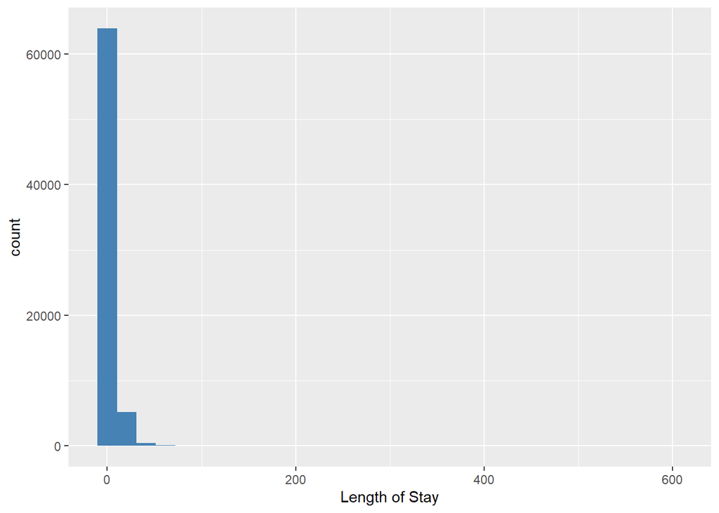

```r
ggplot(icu_table,aes(los)) + geom_histogram(fill = "steelblue") +
  labs(x = "Length of Stay")
```

First ICU unit

```r
icu_table %>% group_by(first_careunit) %>% summarise(N = n())
```

```
## # A tibble: 11 x 2
##    first_careunit                                       N
##    <chr>                                            <int>
##  1 Cardiac Vascular Intensive Care Unit (CVICU)     10920
##  2 Coronary Care Unit (CCU)                          7985
##  3 Medical Intensive Care Unit (MICU)               15587
##  4 Medical/Surgical Intensive Care Unit (MICU/SICU) 12206
##  5 Medicine                                            11
##  6 Neuro Intermediate                                1240
##  7 Neuro Stepdown                                     861
##  8 Neuro Surgical Intensive Care Unit (Neuro SICU)   1558
##  9 PACU                                                68
## 10 Surgical Intensive Care Unit (SICU)              10915
## 11 Trauma SICU (TSICU)                               8268
```

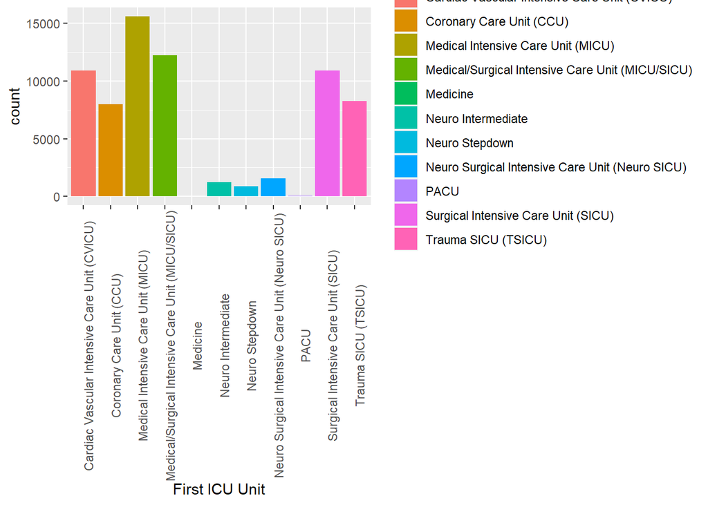

```r
ggplot(icu_table,aes(first_careunit)) +
  geom_bar(mapping = aes(fill = first_careunit)) +
  theme(axis.text.x = element_text(angle = 90)) + labs(x = "First ICU Unit")
```

Last ICU unit

```r
icu_table %>% group_by(last_careunit) %>% summarise(N = n())
```

```
## # A tibble: 9 x 2
##   last_careunit                                        N
##   <chr>                                            <int>
## 1 Cardiac Vascular Intensive Care Unit (CVICU)     10946
## 2 Coronary Care Unit (CCU)                          7859
## 3 Medical Intensive Care Unit (MICU)               16221
## 4 Medical/Surgical Intensive Care Unit (MICU/SICU) 12069
## 5 Neuro Intermediate                                1663
## 6 Neuro Stepdown                                    1200
## 7 Neuro Surgical Intensive Care Unit (Neuro SICU)    906
## 8 Surgical Intensive Care Unit (SICU)              10874
## 9 Trauma SICU (TSICU)                               7881
```

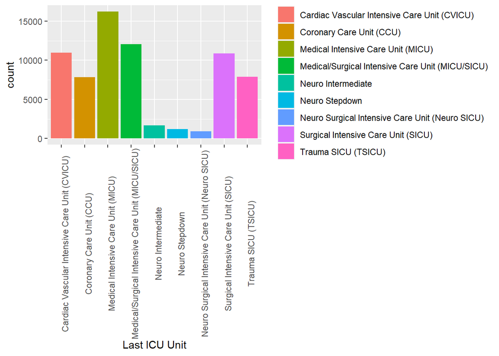

```r
ggplot(icu_table,aes(last_careunit)) +
  geom_bar(mapping = aes(fill = last_careunit)) +
  theme(axis.text.x = element_text(angle = 90)) + labs(x = "Last ICU Unit")
```

## Q4. `admission` data

Information of the patients admitted into hospital is available in `ADMISSION.csv.gz`. See https://mimic-iv.mit.edu/docs/datasets/core/admissions/ for details of each field in this file. Summarize following variables using appropriate graphs. Explain any patterns you observe.

- admission year
- admission month
- admission month day
- admission week day
- admission hour (anything unusual?)
- number of deaths in each year
- admission type
- number of admissions per patient
- admission location
- discharge location
- insurance
- language
- martial status
- ethnicity
- death

Note it is possible that one patient (uniquely identified by the `SUBJECT_ID`) is admitted into hospital multiple times. When summarizing some demographic information, it makes sense to summarize based on unique patients.

**Solution:**

```r
admit_table <- read_csv(str_c(mimic_path, "/mimic-iv/core/admissions.csv.gz"))
admit_table
```

```
## # A tibble: 524,520 x 15
##    subject_id hadm_id admittime           dischtime
##         <dbl>   <dbl> <dttm>              <dttm>
##  1   12427812  2.16e7 2184-01-06 11:51:00 2184-01-10 11:45:00
##  2   14029832  2.21e7 2120-01-18 01:28:00 2120-01-20 16:13:00
##  3   14495017  2.25e7 2175-01-28 15:41:00 2175-01-29 16:00:00
##  4   13676048  2.39e7 2193-01-19 05:27:00 2193-01-24 18:59:00
##  5   13831972  2.78e7 2131-01-27 04:03:00 2131-01-27 05:39:00
##  6   18523038  2.54e7 2142-08-26 17:14:00 2142-08-27 10:00:00
##  7   16705931  2.06e7 2174-10-24 11:30:00 2174-10-24 18:45:00
##  8   19963742  2.50e7 2171-07-04 15:58:00 2171-07-05 13:37:00
##  9   10903424  2.26e7 2181-01-31 13:09:00 2181-01-31 13:42:00
## 10   15030422  2.20e7 2149-09-21 23:54:00 2149-09-22 03:59:00
## # ... with 524,510 more rows, and 11 more variables: deathtime <dttm>,
## #   admission_type <chr>, admission_location <chr>, discharge_location <chr>,
## #   insurance <chr>, language <chr>, marital_status <chr>, ethnicity <chr>,
## #   edregtime <dttm>, edouttime <dttm>, hospital_expire_flag <dbl>
```

Admission Year

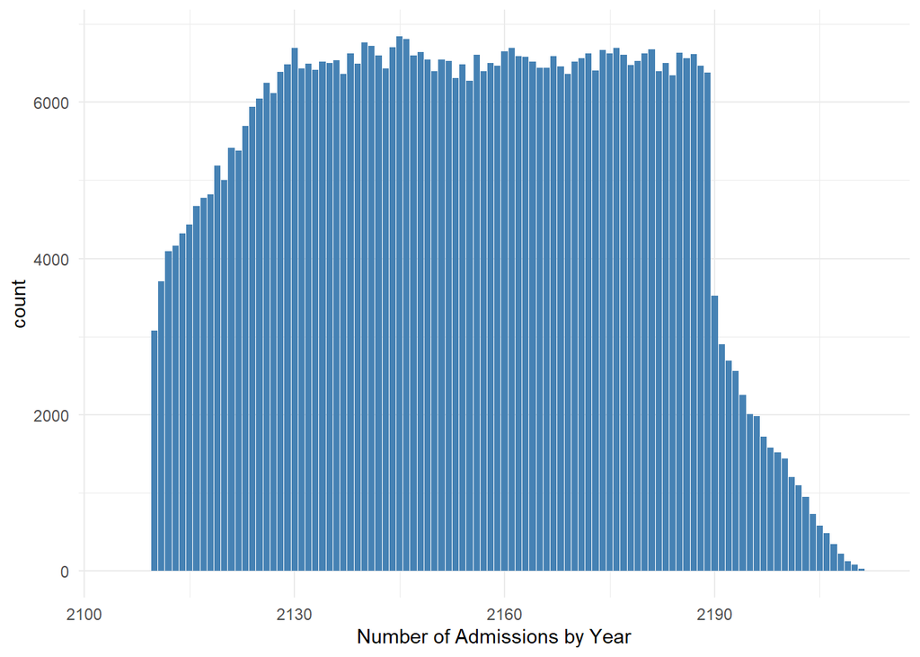

```r
ggplot(admit_table, aes(year(admittime))) + geom_bar(fill = "steelblue") +
  theme_minimal() + labs(x = "Number of Admissions by Year")
```

It appears that admission start our rising before flattening out by ~2130 and then starting a large decline around ~2190.I did not restrict my analysis to unique patients because I wanted to see all admissions that occurred each year.

Admission Month

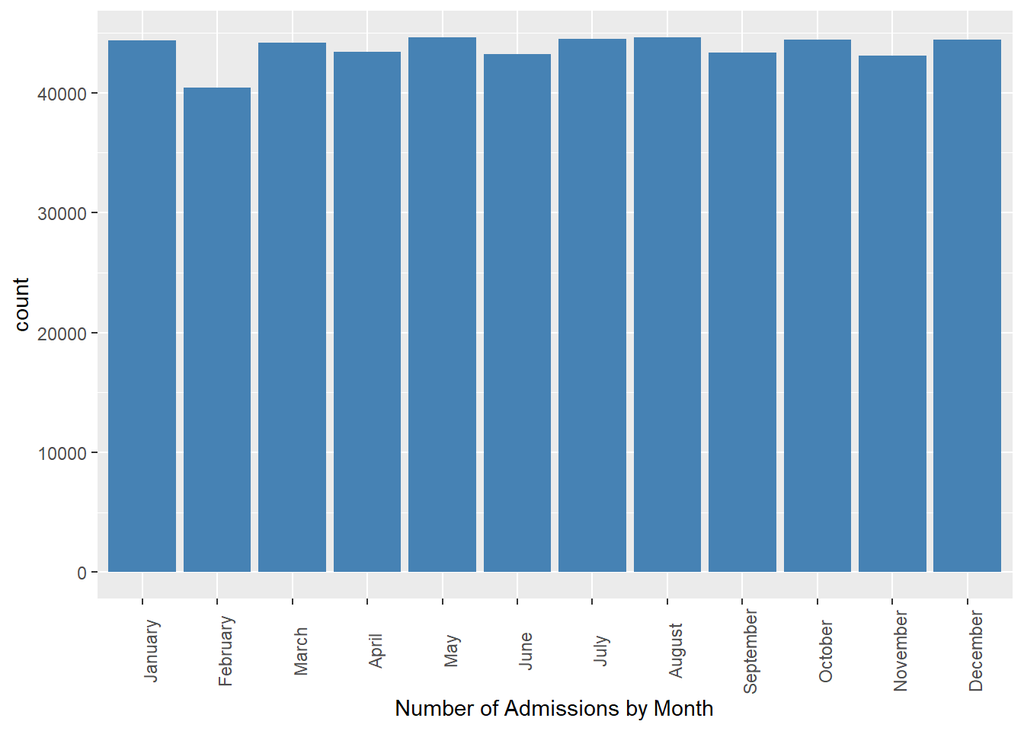

```r
ggplot(admit_table,aes(month(admittime, label = TRUE, abbr = FALSE))) +
  geom_bar(fill = "steelblue") + theme(axis.text.x = element_text(angle = 90)) +
  labs(x = "Number of Admissions by Month")
```

There are slight differences in number of admissions by month, but overall it looks close to uniformly distributed. Parts of the difference could be due to the different amount of days per month. I did not restrict my analysis to unique patients because I wanted to see all admissions that occurred each month.

Admission Month Day

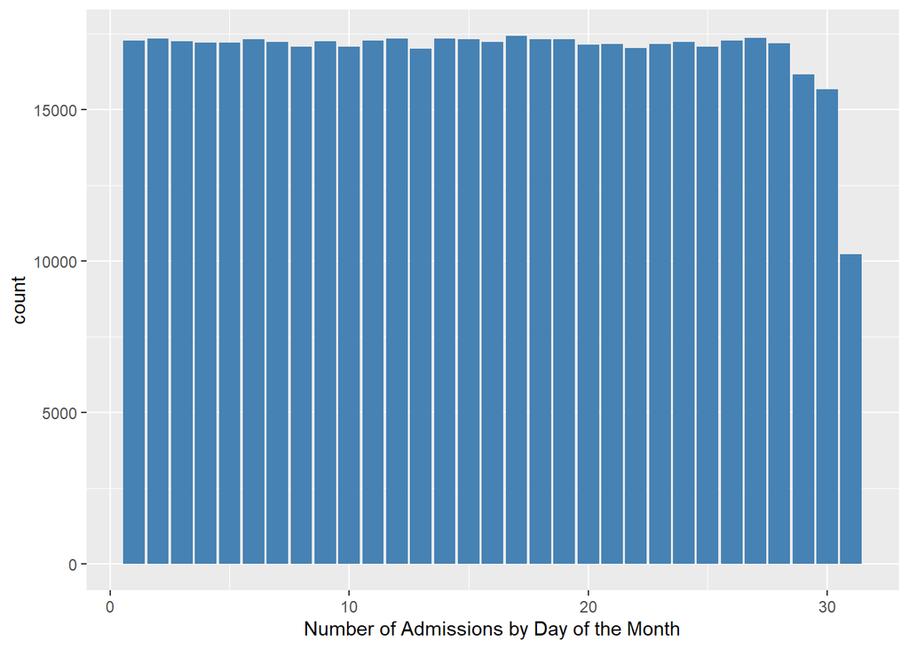

```r
ggplot(admit_table, aes(mday(admittime))) + geom_bar(fill = "steelblue") +
  labs(x = "Number of Admissions by Day of the Month")
```

Most days of the month have approximately equal admissions, but admissions on the 29th, 30th, and 31st are lower. This is probably due to not all months having those days. I did not restrict my analysis to unique patients because I wanted to see all admissions that occurred each day of the month.

Admission Week Day

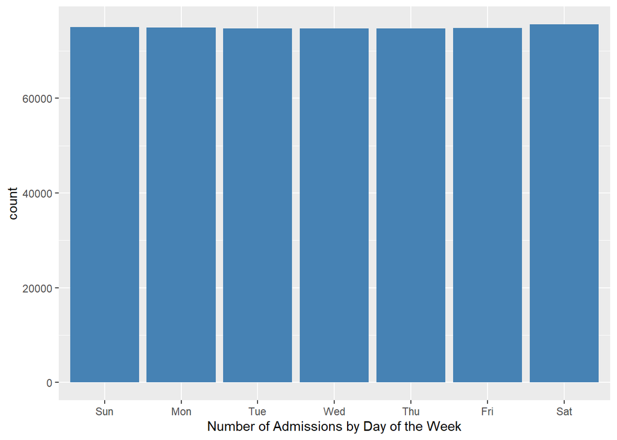

```r
ggplot(admit_table, aes(wday(admittime, label = TRUE, abbr = TRUE))) +
  geom_bar(fill = "steelblue") +
  labs(x = "Number of Admissions by Day of the Week")
```

Admissions by day of the week appear to be roughly uniformly distributed. I did not restrict my analysis to unique patients because I wanted to see all admissions that occurred each day of the week.

Deaths in Each Year

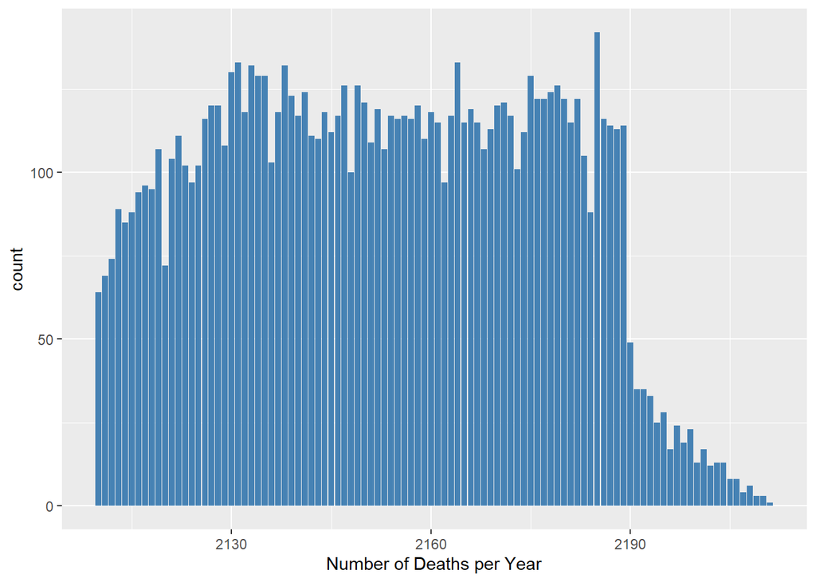

```r
admit_table %>% drop_na(deathtime) %>% ggplot(aes(year(deathtime))) + geom_bar(
  fill = "steelblue") + labs(x = "Number of Deaths per Year")
```

Admission Type

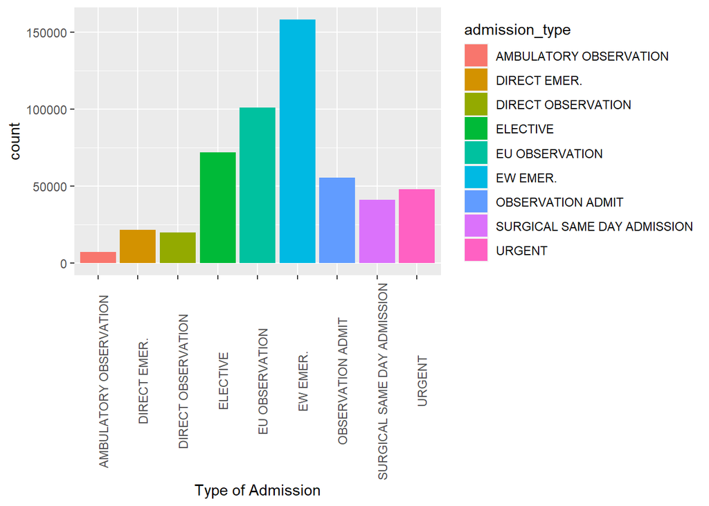

```r
ggplot(admit_table, aes(admission_type)) +
  geom_bar(mapping = aes(fill = admission_type)) +
  theme(axis.text.x = element_text(angle=90)) + labs(x = "Type of Admission")
```

The most admissions appear to occur in EW EMER. EU OBSERVATION and ELECTIVE are the next most common admissions, followed by OBSERVATION ADMIT, URGENT, SURGICAL SAME DAY, DIRECT EMER., DIRECT OBSERVATION, and then AMBULATORY OBSERVATION. I did not choose to analyze this by unique patients, because patients could have multiple different admissions of different types and I wanted to show which admission types were the most common for the hospital.

Number of Admissions per Patient

```r
num_admit <- admit_table %>% group_by(subject_id) %>% summarise(N = n())
num_admit %>% summarise(Min = min(N), Max = max(N), Median = median(N),
                          Mean = mean(N), N = n())
```

```
## # A tibble: 1 x 5
##     Min   Max Median  Mean      N
##   <int> <int>  <dbl> <dbl>  <int>
## 1     1   238      1  2.04 257366
```

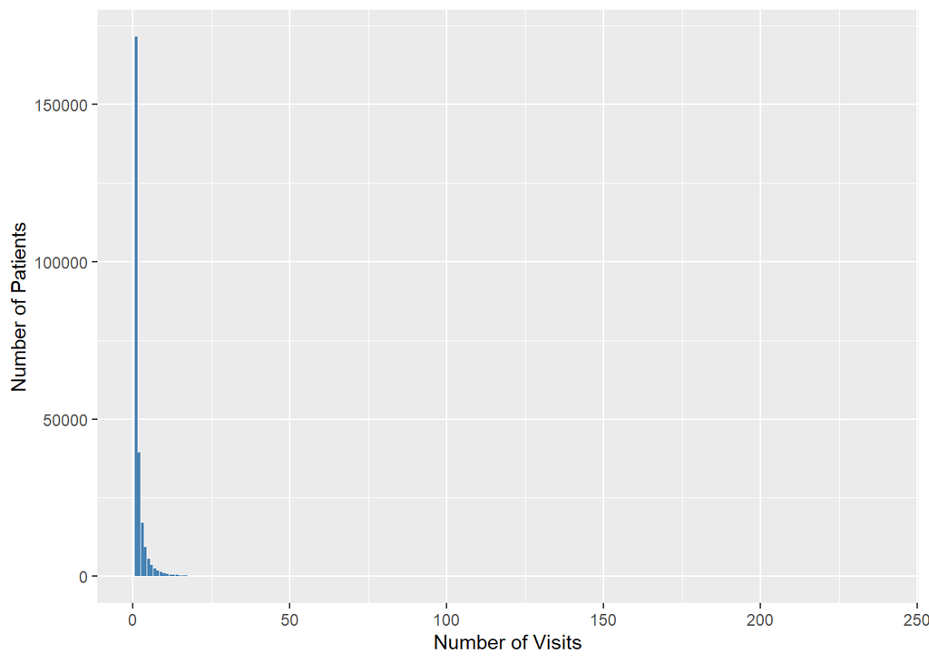

```r
ggplot(num_admit, aes(N)) + geom_bar(fill = "steelblue") +
  labs(x = "Number of Visits", y = "Number of Patients")
```

The largest amount of subjects had one admission. As the number of admissions increases, the number of patients who have been admitted that many times appears to decrease exponentially. I conducted this analysis for unique patients because we are analyzing the number of visits by each unique patient.

Admission Location

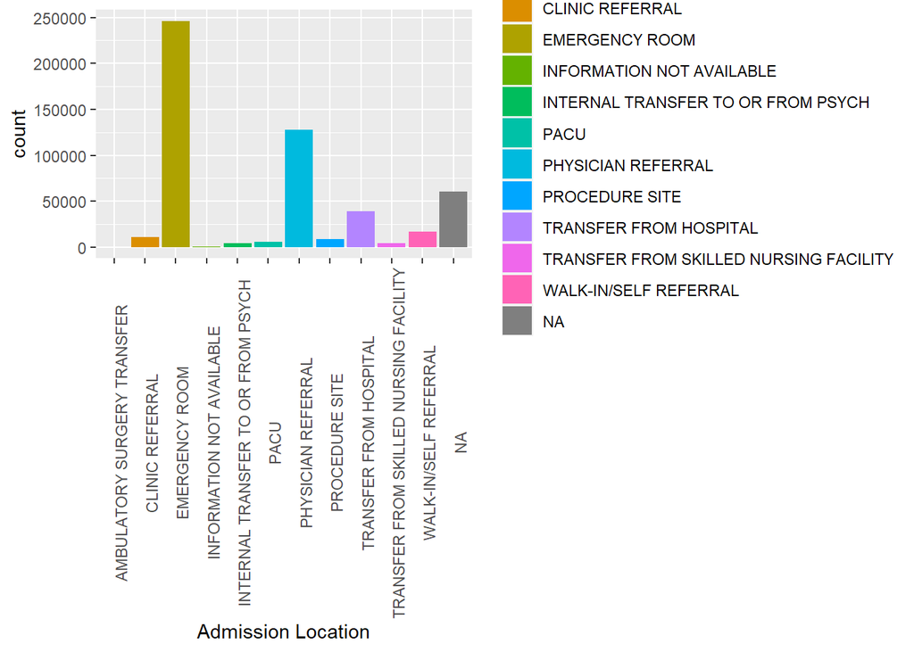

```r
ggplot(admit_table, aes(admission_location)) +
  geom_bar(mapping = aes(fill = admission_location)) +
  theme(axis.text.x = element_text(angle = 90)) + labs(x = "Admission Location")
```

Emergency room and physician referral appears to be much more common admission locations than other locations. I did not choose to analyze by unique patient because I wanted to show which locations have the most admissions.

Discharge Location

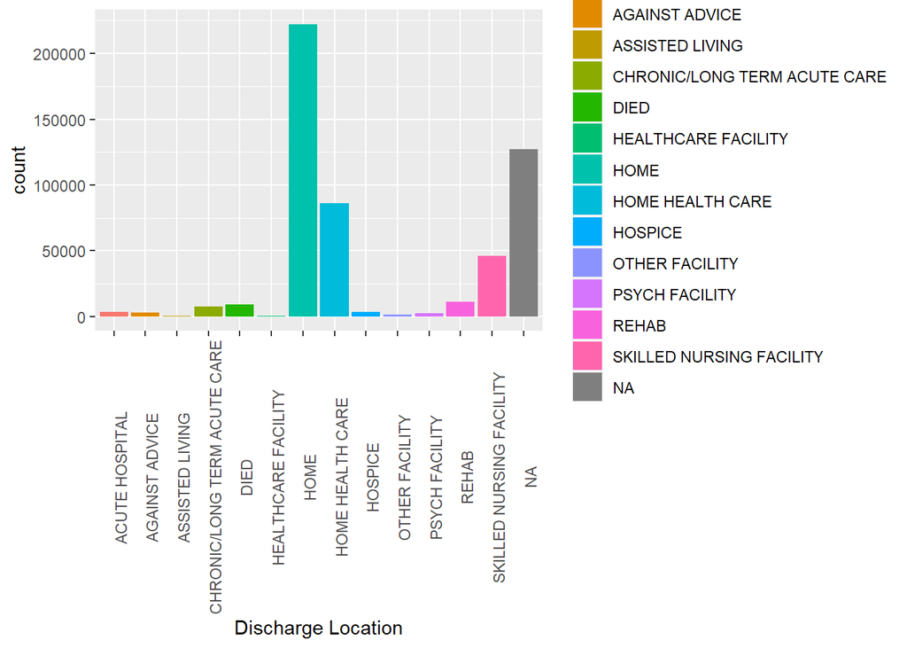

```r
ggplot(admit_table, aes(discharge_location)) +
  geom_bar(mapping = aes(fill = discharge_location)) +
  theme(axis.text.x = element_text(angle = 90)) + labs(x = "Discharge Location")
```

Most patients were discharged to home, although there is a large amount of “N/A” observations. I did not choose to analyze by unique patient because I wanted to show the outcomes (discharge location) for each admission.

Insurance

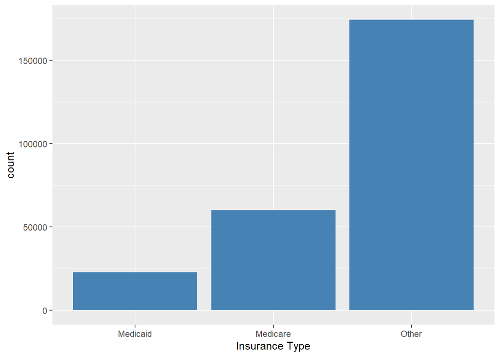

```r
distinct(admit_table, subject_id, .keep_all = TRUE) %>% ggplot(aes(insurance)) +
  geom_bar(fill = "steelblue") + labs(x = "Insurance Type")
```

Most patients health insurance is “Other”, followed by “Medicare” and then “Medicaid”. I chose to analyze distinct patients because I didn’t want some types of insurance to be over counted due to some patients visiting many times.

Language

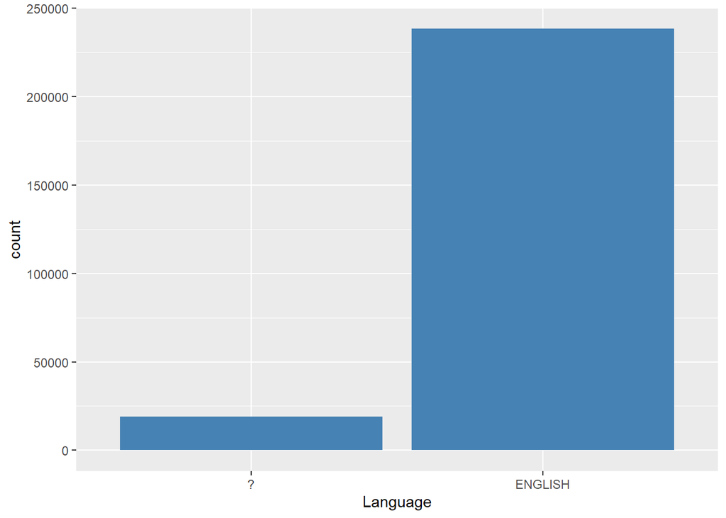

```r
distinct(admit_table, subject_id, .keep_all = TRUE) %>% ggplot(aes(language)) +
geom_bar(fill = "steelblue") + labs(x = "Language")
```

The vast majority of patients’ language was English. Other languages were categorized as “?”. I chose to analyze distinct patients because I didn’t want some languages to be over counted due to some patients visiting many times.

Martial status

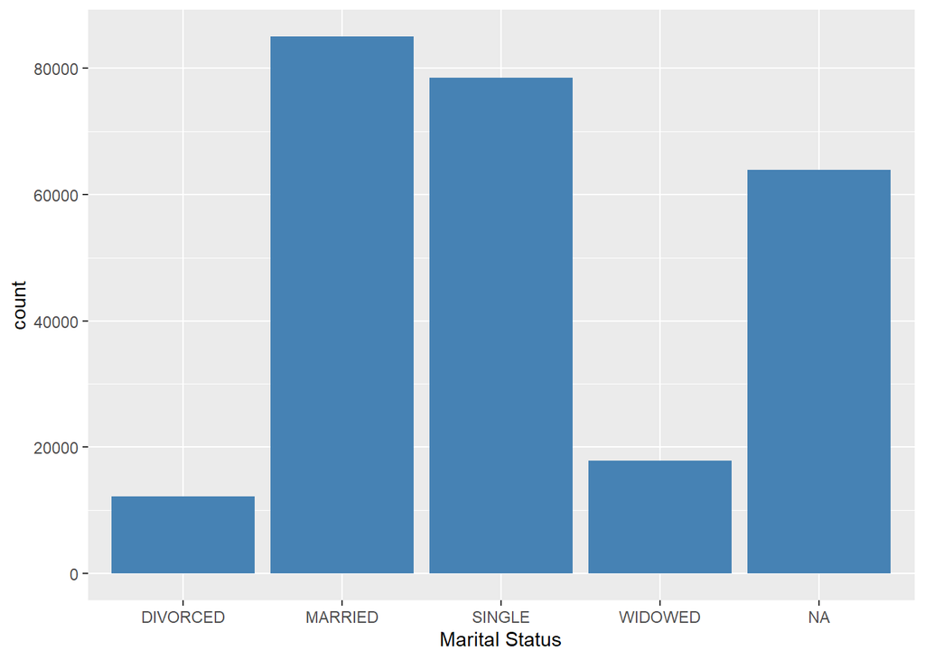

```r
distinct(admit_table, subject_id, .keep_all = TRUE) %>%
  ggplot(aes(marital_status)) + geom_bar(fill = "steelblue") +
  labs(x = "Marital Status")
```

Married and single are the largest groups, but there is a large group with N/A for marital status. Each patient was only counted once so certain marital statuses weren’t over counted.

Ethnicity

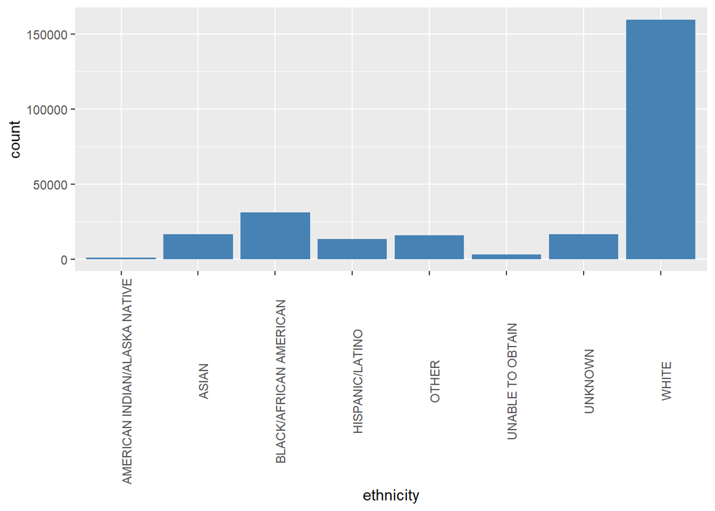

```r
distinct(admit_table, subject_id, .keep_all = TRUE) %>%
  ggplot(aes(ethnicity)) + geom_bar(fill = "steelblue") +
  theme(axis.text.x = element_text(angle = 90))
```

The majority of patients in this data set are white. I chose to analyze distinct patients because I didn’t want some ethnic groups to be over counted due to different rates of health care use.

Death (Need to change x axis info)

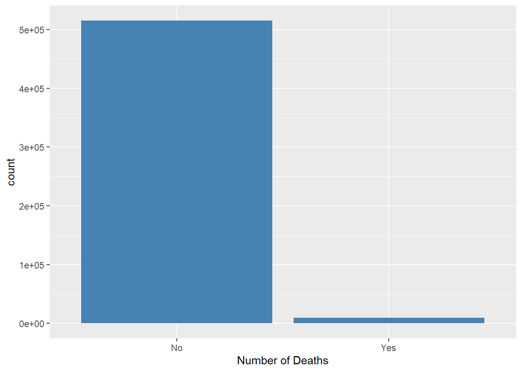

```r
admit_table$deathflag = "No"
admit_table[admit_table$hospital_expire_flag == 1, 16] = "Yes"

admit_table %>% ggplot(aes(deathflag)) +
  geom_bar(fill = "steelblue") + labs(x = "Number of Deaths")
```

The vast majority of hospital admissions do not have a death occur. I did not choose to analyze this by distinct patients because it a patient could be admitted multiple times but only can die once and it is more important to understand how many hospital admissions have a death occur, instead of how many unique admitted patients died.

## Q5. `patient` data

Explore `patients.csv.gz` (https://mimic-iv.mit.edu/docs/datasets/core/patients/) and summarize following variables using appropriate numerics and graphs:

- `gender`
- `anchor_age` (explain pattern you see) **Solution:**

```r
pat_table <- read_csv(str_c(mimic_path, "/mimic-iv/core/patients.csv.gz"))
pat_table
```

```
## # A tibble: 383,220 x 6
##    subject_id gender anchor_age anchor_year anchor_year_group dod
##         <dbl> <chr>       <dbl>       <dbl> <chr>             <lgl>
##  1   10002723 F               0        2128 2017 - 2019       NA
##  2   10003939 M               0        2184 2008 - 2010       NA
##  3   10004222 M               0        2161 2014 - 2016       NA
##  4   10005325 F               0        2154 2011 - 2013       NA
##  5   10007338 F               0        2153 2017 - 2019       NA
##  6   10008101 M               0        2142 2008 - 2010       NA
##  7   10009872 F               0        2168 2014 - 2016       NA
##  8   10011333 F               0        2132 2014 - 2016       NA
##  9   10011879 M               0        2158 2014 - 2016       NA
## 10   10012663 F               0        2171 2011 - 2013       NA
## # ... with 383,210 more rows
```

Gender

```r
pat_table %>% group_by(gender) %>% summarise(N = n())
```

```
## # A tibble: 2 x 2
##   gender      N
##   <chr>   <int>
## 1 F      200226
## 2 M      182994
```

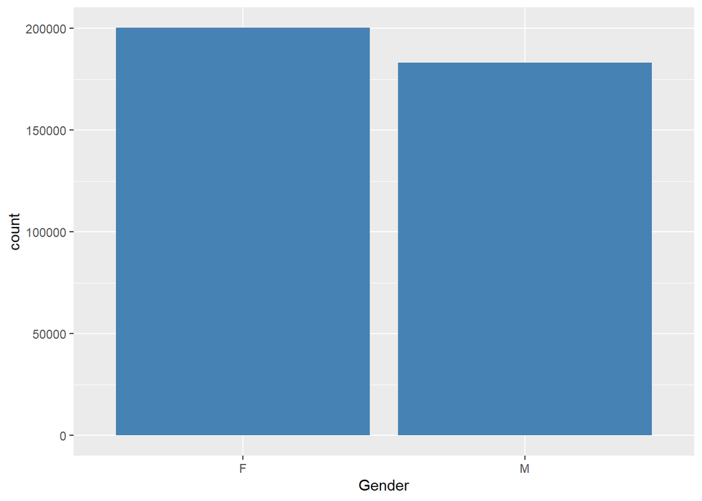

```r
  ggplot(pat_table,aes(gender)) + geom_bar(fill = "steelblue") +
  labs(x = "Gender")
```

Anchor Age

```r
pat_table %>% summarise(Avg = mean(anchor_age), StDev = sd(anchor_age),
                        Min = min(anchor_age), Q1 = quantile(anchor_age, 0.25),
                        Median = quantile(anchor_age, 0.5),
                        Q3 = quantile(anchor_age, 0.75), Max = max(anchor_age))
```

```
## # A tibble: 1 x 7
##     Avg StDev   Min    Q1 Median    Q3   Max
##   <dbl> <dbl> <dbl> <dbl>  <dbl> <dbl> <dbl>
## 1  40.9  26.1     0    22     41    62    91
```

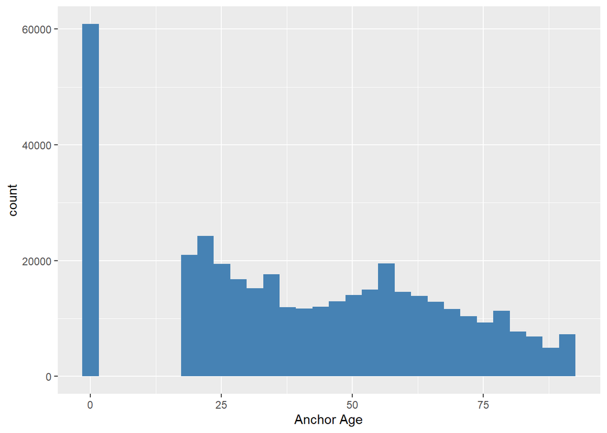

```r
ggplot(pat_table,aes(anchor_age)) + geom_histogram(fill = "steelblue") +
  labs(x = "Anchor Age")
```

There is a large amount of patients with an anchor_age of zero, this doesn’t make sense, so this probably means those anchor_ages are missing, but we should verify. Otherwise, there appears to be a sinusoidal, but overall decreasing pattern to the data.

## Q6. Lab results

`labevents.csv.gz` (https://mimic-iv.mit.edu/docs/datasets/hosp/labevents/) contains all laboratory measurements for patients.

We are interested in the lab measurements of creatinine (50912), potassium (50971), sodium (50983), chloride (50902), bicarbonate (50882), hematocrit (51221), white blood cell count (51301), glucose (50931), magnesium (50960), calcium (50893), and lactate (50813). Find the `itemid`s of these lab measurements from `d_labitems.csv.gz` and retrieve a subset of `labevents.csv.gz` only containing these items.

**Solution:** Reads in the Lab Item Dictionary.

```r
dlabitems <- read_csv(str_c(mimic_path, "/mimic-iv/hosp/d_labitems.csv.gz")) %>%
  print(width = Inf)
```

```
## # A tibble: 1,625 x 5
##    itemid label                     fluid            category   loinc_code
##     <dbl> <chr>                     <chr>            <chr>      <chr>
##  1  51898 <NA>                      Other Body Fluid Chemistry  <NA>
##  2  51532 11-Deoxycorticosterone    Blood            Chemistry  <NA>
##  3  51952 17-Hydroxycorticosteroids Urine            Chemistry  <NA>
##  4  51953 17-Ketosteroids, Urine    Urine            Chemistry  <NA>
##  5  52063 24 Hr                     Blood            Hematology <NA>
##  6  51066 24 hr Calcium             Urine            Chemistry  <NA>
##  7  51067 24 hr Creatinine          Urine            Chemistry  <NA>
##  8  51068 24 hr Protein             Urine            Chemistry  <NA>
##  9  50853 25-OH Vitamin D           Blood            Chemistry  <NA>
## 10  51533 3t                        Blood            Chemistry  <NA>
## # ... with 1,615 more rows
```

Reads in the large labevents file, if the smaller filtered down file does not exist. Filters the file down based on ICU stays and a writes it to an intermediary file.

```r
if(!file.exists("labevents_icustays.csv.gz")){
  system.time(labevents <- fread(str_c(mimic_path, "/hosp/labevents.csv.gz"),
                              select = c("subject_id", "hadm_id", "itemid",
                                         "charttime", "valuenum"), nThread = 8))
  labevents_tble <- as_tibble(labevents)
  system.time(labevents_tble %>% semi_join(icu_table,
  by = c("subject_id", "hadm_id")) %>% fwrite("labevents_icustays.csv.gz"))
}
```

Reads the intermediary file back into R.

```r
system.time(lab_icu <- read_csv("labevents_icustays.csv.gz"))
```

```
##    user  system elapsed
##   39.97   16.39   56.77
```

Finds the most common lab items of each type and creates a list of those items.

```r
labitems <- c("creatinine", "potassium", "sodium", "chloride", "bicarbonate",
             "hematocrit", "white blood cell", "glucose", "magnesium",
             "calcium", "lactate")
itemids <- rep(0, length(labitems))
i <- 1
for (labitem in labitems) {
  print(str_interp("Searching for ${labitem}"))
  itemid_list <- dlabitems %>% filter(str_detect(label,
                                      regex(labitem, ignore_case = TRUE))) %>%
    .$itemid
  itemid <- lab_icu %>% filter(itemid %in% itemid_list) %>%
    count(itemid) %>% arrange(desc(n)) %>% slice(1) %>% .$itemid
  itemids[i] <- itemid
  i <- i + 1
}
```

```
## [1] "Searching for creatinine"
## [1] "Searching for potassium"
## [1] "Searching for sodium"
## [1] "Searching for chloride"
## [1] "Searching for bicarbonate"
## [1] "Searching for hematocrit"
## [1] "Searching for white blood cell"
## [1] "Searching for glucose"
## [1] "Searching for magnesium"
## [1] "Searching for calcium"
## [1] "Searching for lactate"
```

Puts these lab items in a tibble for ease of reference and viewing.

```r
labitem_list <- tibble(labitem = labitems, itemid = itemids) %>%
  print(width = Inf)
```

```
## # A tibble: 11 x 2
##    labitem          itemid
##    <chr>             <dbl>
##  1 creatinine        50912
##  2 potassium         50971
##  3 sodium            50983
##  4 chloride          50902
##  5 bicarbonate       50882
##  6 hematocrit        51221
##  7 white blood cell  51301
##  8 glucose           50931
##  9 magnesium         50960
## 10 calcium           50893
## 11 lactate           50813
```

Creates a subset of only the lab items that we want for further analysis.

```r
labevent_subset <- filter(lab_icu, itemid %in% itemids) %>% print(width = Inf)
```

```
## # A tibble: 8,021,352 x 5
##    subject_id  hadm_id itemid charttime           valuenum
##         <dbl>    <dbl>  <dbl> <dttm>                 <dbl>
##  1   12457441 21673651  50882 2135-08-16 23:45:00     28
##  2   12457441 21673651  50893 2135-08-16 23:45:00      7.5
##  3   12457441 21673651  50902 2135-08-16 23:45:00     95
##  4   12457441 21673651  50912 2135-08-16 23:45:00      0.6
##  5   12457441 21673651  50960 2135-08-16 23:45:00      1.5
##  6   12457441 21673651  50971 2135-08-16 23:45:00      3
##  7   12457441 21673651  50983 2135-08-16 23:45:00    133
##  8   12457441 21673651  51221 2135-08-16 23:45:00     14.8
##  9   12457441 21673651  51301 2135-08-16 23:45:00      3.3
## 10   12457441 21673651  50813 2135-08-17 00:02:00      2
## # ... with 8,021,342 more rows
```

## Q7. Vitals from chartered events

We are interested in the vitals for ICU patients: heart rate, mean and systolic blood pressure (invasive and noninvasive measurements combined), body temperature, SpO2, and respiratory rate. Find the `itemid`s of these vitals from `d_items.csv.gz` and retrieve a subset of `chartevents.csv.gz` only containing these items.

`chartevents.csv.gz` (https://mimic-iv.mit.edu/docs/datasets/icu/chartevents/) contains all the charted data available for a patient. During their ICU stay, the primary repository of a patient’s information is their electronic chart. The `itemid` variable indicates a single measurement type in the database. The `value` variable is the value measured for `itemid`.

`d_items.csv.gz` (https://mimic-iv.mit.edu/docs/datasets/icu/d_items/) is the dictionary for the `itemid` in `chartevents.csv.gz`.

**Solution:** I set my code to not evaluate when knit because I can barely get it to run on my system and not at all on the teaching server. I have included it here for reference, but I ended up using the provided filtered data file from Dr. Zhou for this homework assignment.

Reads in the dictionary for the chart events for the ICU.

```r
ditems<-read_csv(str_c(mimic_path, "/mimic-iv/icu/d_items.csv.gz")) %>%
  print(width = Inf)
```

Lists the most common chart items for each vital sign that is wanted.

```r
for (chartitem in c("heartrate", "Blood Pressure mean", "systolic",
                    "temperature", "SpO2", "respiratory rate")) {
  print(str_interp("searching for ${chartitem}"))
  ditems %>% filter(str_detect(label, regex(chartitem, ignore_case = T))) %>%
  print(width = Inf)
}
```

Reads in the chartevents file, which is very large, into R if the intermediary file doesn’t exist.

```r
if(!file.exists("chart_icustays.csv.gz")){
system.time(chart <- fread(str_c(mimic_path, "/mimic-iv/icu/chartevents.csv.gz"),
                           select = c("hadm_id", "itemid",
                                      "charttime", "valuenum"), nThread = 8))
}
```

Creates a stripped down set of data and writes it to an intermediary file. This intermediary file is still over 1GB in size.

```r
system.time(as_tibble(chart) %>% semi_join(icu_table, by = c("hadm_id")) %>%
  fwrite("chart_icustays.csv.gz", nThread = 8))
```

Reads the intermediary file back into R.

```r
system.time(chart_icu <- fread(str_c("chart_icustays.csv.gz"),
            nThread=8))
```

Outputs a subset of data that contains the most common vitals measurements of the type requested.

```r
chartfil_tble <- filter(chart_icu, itemid=c(220045, 220050, 220052, 220179,
                                            220181, 220210, 223761)) %>%
  print(width = Inf)
```

Due to performance issues. I used the below code to read in the pre-filtered data set from Dr. Zhou.

```r
chartfilter <- fread(str_c(mimic_path,
  "/mimic-iv-derived-data/chartevents_filtered_itemid.csv.gz"), header = FALSE,
  col.names = c("subject_id", "hadm_id","stay_id","charttime","itemid",
                "valuenum")) %>% print()
```

```
##           subject_id  hadm_id  stay_id           charttime itemid valuenum
##        1:   10003700 28623837 35053963 2165-04-24 05:28:00 220179    152.0
##        2:   10003700 28623837 35053963 2165-04-24 05:28:00 220181    110.0
##        3:   10003700 28623837 35053963 2165-04-24 05:30:00 220045     65.0
##        4:   10003700 28623837 35053963 2165-04-24 05:30:00 220210     14.0
##        5:   10003700 28623837 35053963 2165-04-24 05:38:00 223761     97.6
##       ---
## 30095992:   19999068 21606769 31096823 2161-08-30 20:00:00 223761     97.5
## 30095993:   19999068 21606769 31096823 2161-08-30 21:00:00 220045     88.0
## 30095994:   19999068 21606769 31096823 2161-08-30 21:00:00 220179    129.0
## 30095995:   19999068 21606769 31096823 2161-08-30 21:00:00 220181     95.0
## 30095996:   19999068 21606769 31096823 2161-08-30 21:00:00 220210     15.0
```

Converts the stripped down data to a tibble and changes the charttime variable to a data instead of a character value.

```r
chartfilter_tble <- as_tibble(chartfilter) %>%
  mutate(charttime=ymd_hms(charttime)) %>% print(width = Inf)
```

```
## # A tibble: 30,095,996 x 6
##    subject_id  hadm_id  stay_id charttime           itemid valuenum
##         <int>    <int>    <int> <dttm>               <int>    <dbl>
##  1   10003700 28623837 35053963 2165-04-24 05:28:00 220179    152
##  2   10003700 28623837 35053963 2165-04-24 05:28:00 220181    110
##  3   10003700 28623837 35053963 2165-04-24 05:30:00 220045     65
##  4   10003700 28623837 35053963 2165-04-24 05:30:00 220210     14
##  5   10003700 28623837 35053963 2165-04-24 05:38:00 223761     97.6
##  6   10003700 28623837 35053963 2165-04-24 06:00:00 220045     56
##  7   10003700 28623837 35053963 2165-04-24 06:00:00 220179    126
##  8   10003700 28623837 35053963 2165-04-24 06:00:00 220181     88
##  9   10003700 28623837 35053963 2165-04-24 06:00:00 220210     14
## 10   10003700 28623837 35053963 2165-04-24 06:09:00 220045     55
## # ... with 30,095,986 more rows
```

Removing the chartfilter data.table from memory, as it is now a duplicate.

```r
rm(chartfilter)
gc()
```

```
##             used   (Mb) gc trigger   (Mb)  max used   (Mb)
## Ncells   1308045   69.9    8588417  458.7   5841152  312.0
## Vcells 346077530 2640.4  899167079 6860.2 887057312 6767.8
```

## Q8. Putting things together

Let us create a tibble for all ICU stays, where rows are

- first ICU stay of each unique patient
- adults (age at admission > 18)

and columns contains at least following variables

- all variables in `icustays.csv.gz`
- all variables in `admission.csv.gz`
- first lab measurements during ICU stay
- first vitals measurement during ICU stay
- an indicator variable whether the patient died within 30 days of hospital admission

This creates a tibble of the first chart event for each vital sign. We won’t use this until later, but it lets us deallocate the data from Q7, which is very memory intensive.

```r
chartfilter_uniq <- chartfilter_tble %>%
  left_join(select(icu_table, subject_id, hadm_id, intime), by =
            c("subject_id", "hadm_id")) %>% filter(charttime >= intime) %>%
  group_by(subject_id, itemid) %>%
  arrange(intime, .by_group = TRUE) %>% slice_head(n = 1) %>%
  arrange(charttime, .by_group = TRUE) %>% slice_head(n = 1) %>%
  print(width = Inf)
```

```
## # A tibble: 295,740 x 7
## # Groups:   subject_id, itemid [295,740]
##    subject_id  hadm_id  stay_id charttime           itemid valuenum
##         <dbl>    <dbl>    <int> <dttm>               <int>    <dbl>
##  1   10000032 29079034 37529680 2180-07-23 14:12:00 220045     91
##  2   10000032 29079034 37529680 2180-07-23 14:11:00 220179     84
##  3   10000032 29079034 37529680 2180-07-23 14:11:00 220181     56
##  4   10000032 29079034 37529680 2180-07-23 14:12:00 220210     24
##  5   10000032 29079034 37529680 2180-07-23 14:00:00 223761     98.7
##  6   10000980 26913865 36742749 2189-06-27 08:56:00 220045     77
##  7   10000980 26913865 36742749 2189-06-27 08:55:00 220179    150
##  8   10000980 26913865 36742749 2189-06-27 08:55:00 220181     92
##  9   10000980 26913865 36742749 2189-06-27 08:54:00 220210     23
## 10   10000980 26913865 36742749 2189-06-27 09:07:00 223761     98
##    intime
##    <dttm>
##  1 2180-07-23 14:00:00
##  2 2180-07-23 14:00:00
##  3 2180-07-23 14:00:00
##  4 2180-07-23 14:00:00
##  5 2180-07-23 14:00:00
##  6 2189-06-27 08:42:00
##  7 2189-06-27 08:42:00
##  8 2189-06-27 08:42:00
##  9 2189-06-27 08:42:00
## 10 2189-06-27 08:42:00
## # ... with 295,730 more rows
```

Now that we have generated a smaller data set from this, we deallocate the larger tibble from memory so we improve performance and reduce issues due to lack of memory.

```r
rm(chartfilter_tble)
gc()
```

```
##             used   (Mb) gc trigger   (Mb)  max used   (Mb)
## Ncells   1608929   86.0    5496588  293.6   8588417  458.7
## Vcells 228515043 1743.5  871734202 6650.9 907989794 6927.5
```

```r
icutble_uniq <- icu_table %>% group_by(subject_id) %>%
  filter(rank(intime) == 1) %>% ungroup() %>%
  left_join(admit_table, by = c("subject_id", "hadm_id")) %>%
  left_join(pat_table, by = "subject_id") %>% mutate(age_at_adm =
  year(admittime) - anchor_year + anchor_age) %>% filter(age_at_adm > 18) %>%
  print(width = Inf)
```

```
## # A tibble: 49,971 x 28
##    subject_id  hadm_id  stay_id first_careunit
##         <dbl>    <dbl>    <dbl> <chr>
##  1   13713711 25848902 36363748 Trauma SICU (TSICU)
##  2   13173210 22338446 38210858 Coronary Care Unit (CCU)
##  3   10213765 28522861 39765853 Trauma SICU (TSICU)
##  4   17530304 21776160 35848367 Trauma SICU (TSICU)
##  5   16766597 21185791 39262919 Trauma SICU (TSICU)
##  6   17684317 28656350 36989766 Trauma SICU (TSICU)
##  7   15693895 21203492 34766377 Surgical Intensive Care Unit (SICU)
##  8   13859862 25015072 31891587 Medical/Surgical Intensive Care Unit (MICU/SICU)
##  9   12200371 27271451 32261832 Medical/Surgical Intensive Care Unit (MICU/SICU)
## 10   13307171 21128752 38043905 Neuro Stepdown
##    last_careunit                                    intime
##    <chr>                                            <dttm>
```

[output cut: 83 more lines]

Merging Lab Results

```r
labmerge <- labevent_subset %>% semi_join(icutble_uniq, by =
                                          c("subject_id", "hadm_id")) %>%
  left_join(select(icutble_uniq, subject_id, hadm_id, intime),
  by = c("subject_id", "hadm_id")) %>% filter(charttime >= intime) %>%
  group_by(subject_id, itemid) %>% arrange(charttime, .by_group=TRUE) %>%
  slice_head(n = 1) %>% select(-charttime, -intime) %>%
  spread(key = itemid, value = valuenum) %>% print(width = Inf)
```

```
## # A tibble: 49,309 x 13
## # Groups:   subject_id [49,309]
##    subject_id  hadm_id `50813` `50882` `50893` `50902` `50912` `50931` `50960`
##         <dbl>    <dbl>   <dbl>   <dbl>   <dbl>   <dbl>   <dbl>   <dbl>   <dbl>
##  1   10000032 29079034    NA        21     9.3     102     0.5     115     2.3
##  2   10000980 26913865    NA        23     9.2     103     2.2     144     2
##  3   10001217 24597018    NA        23     8.2     104     0.4     113     1.9
##  4   10001725 25563031    NA        24     9.1     106     0.8     146     1.5
##  5   10001884 26184834     1.5      33     9.8      96     1.1     148     2.2
##  6   10002013 23581541     3.3      23    NA       109     1.1      98     2.1
##  7   10002155 23822395    NA        25     8.8     106     0.9      95     2
##  8   10002223 22494570    NA        26     8.7     102     0.8      88     2
##  9   10002428 28662225     1.6      20     7.4      98     0.8      99     1.4
## 10   10002443 21329021     1.7      20     7.6     101     0.8     226     1.6
##    `50971` `50983` `51221` `51301`
##      <dbl>   <dbl>   <dbl>   <dbl>
##  1     4.7     132    34.8     4.1
##  2     4.2     139    30.8     5.4
##  3     3.6     138    33.6    19
##  4     3.9     140    39.1    17
##  5     4       136    36      18.4
##  6     4       140    28.6    18.2
##  7     4.5     139    37.9     5.5
##  8     3.9     138    32.5    10.1
##  9     3.9     129    28.7    22.4
## 10     5.2     133    43.4    20.7
## # ... with 49,299 more rows
```

Renaming our columns to the lab item names instead of the itemids

```r
labfinal <- labmerge %>% right_join(icutble_uniq, by = c("subject_id",
                                                         "hadm_id")) %>%
  ungroup() %>% rename_at(vars(as.character(labitem_list$itemid)),
                          ~labitem_list$labitem) %>% print(width = Inf)
```

```
## # A tibble: 49,971 x 39
##    subject_id  hadm_id lactate bicarbonate calcium chloride creatinine glucose
##         <dbl>    <dbl>   <dbl>       <dbl>   <dbl>    <dbl>      <dbl>   <dbl>
##  1   10000032 29079034    NA            21     9.3      102        0.5     115
##  2   10000980 26913865    NA            23     9.2      103        2.2     144
##  3   10001217 24597018    NA            23     8.2      104        0.4     113
##  4   10001725 25563031    NA            24     9.1      106        0.8     146
##  5   10001884 26184834     1.5          33     9.8       96        1.1     148
##  6   10002013 23581541     3.3          23    NA        109        1.1      98
##  7   10002155 23822395    NA            25     8.8      106        0.9      95
##  8   10002223 22494570    NA            26     8.7      102        0.8      88
##  9   10002428 28662225     1.6          20     7.4       98        0.8      99
## 10   10002443 21329021     1.7          20     7.6      101        0.8     226
##    magnesium potassium sodium hematocrit `white blood cell`  stay_id
##        <dbl>     <dbl>  <dbl>      <dbl>              <dbl>    <dbl>
```

[output cut: 107 more lines]

Removing more data no longer needed from memory to improve performance.

```r
rm(labmerge, lab_icu, labevent_subset, dlabitems, labitems, labitem_list,
  chartfilter)
gc()
```

```
##            used  (Mb) gc trigger   (Mb)  max used   (Mb)
## Ncells  1615407  86.3    5496588  293.6   8588417  458.7
## Vcells 57007914 435.0  697387362 5320.7 907989794 6927.5
```

```r
chartids = c(220045, 220050, 220052, 220179, 220181, 220210, 223761)
chartnames = c("HeartRate", "Arterial Blood Pressure Mean",
               "Arterial Blood Pressure Systolic",
               "Non-Invasive Systolic Pressure",
               "Non-Invasive Blood Pressure Mean",
               "Temperature (F)", "Respiratory Rate")
full_tble <- labfinal %>% left_join(chartfilter_uniq, by = c("subject_id",
                                    "hadm_id", "intime", "stay_id")) %>%
  select(-charttime, -stay_id) %>% spread(key = itemid,
  value = valuenum) %>% rename_at(vars(as.character(chartids)),
                          ~chartnames) %>% print(width = Inf)
```

```
## # A tibble: 49,971 x 46
##    subject_id  hadm_id lactate bicarbonate calcium chloride creatinine glucose
##         <dbl>    <dbl>   <dbl>       <dbl>   <dbl>    <dbl>      <dbl>   <dbl>
##  1   10000032 29079034    NA            21     9.3      102        0.5     115
##  2   10000980 26913865    NA            23     9.2      103        2.2     144
##  3   10001217 24597018    NA            23     8.2      104        0.4     113
##  4   10001725 25563031    NA            24     9.1      106        0.8     146
##  5   10001884 26184834     1.5          33     9.8       96        1.1     148
##  6   10002013 23581541     3.3          23    NA        109        1.1      98
##  7   10002155 23822395    NA            25     8.8      106        0.9      95
##  8   10002223 22494570    NA            26     8.7      102        0.8      88
##  9   10002428 28662225     1.6          20     7.4       98        0.8      99
## 10   10002443 21329021     1.7          20     7.6      101        0.8     226
##    magnesium potassium sodium hematocrit `white blood cell`
##        <dbl>     <dbl>  <dbl>      <dbl>              <dbl>
```

[output cut: 143 more lines]

```r
full_tble[!is.na(names(full_tble))] %>% mutate(days_to_death =
  difftime(deathtime, intime, units = "days")) %>%
  mutate(died_within_30d = days_to_death<=30) %>%
  replace_na(list(died_within_30d = FALSE)) %>% print(width = Inf)
```

```
## # A tibble: 49,971 x 48
##    subject_id  hadm_id lactate bicarbonate calcium chloride creatinine glucose
##         <dbl>    <dbl>   <dbl>       <dbl>   <dbl>    <dbl>      <dbl>   <dbl>
##  1   10000032 29079034    NA            21     9.3      102        0.5     115
##  2   10000980 26913865    NA            23     9.2      103        2.2     144
##  3   10001217 24597018    NA            23     8.2      104        0.4     113
##  4   10001725 25563031    NA            24     9.1      106        0.8     146
##  5   10001884 26184834     1.5          33     9.8       96        1.1     148
##  6   10002013 23581541     3.3          23    NA        109        1.1      98
##  7   10002155 23822395    NA            25     8.8      106        0.9      95
##  8   10002223 22494570    NA            26     8.7      102        0.8      88
##  9   10002428 28662225     1.6          20     7.4       98        0.8      99
## 10   10002443 21329021     1.7          20     7.6      101        0.8     226
##    magnesium potassium sodium hematocrit `white blood cell`
##        <dbl>     <dbl>  <dbl>      <dbl>              <dbl>
```

[output cut: 143 more lines]